# LBB_Twitter_Sentiment_Analysis

**Twitter Sentiment Analysis**

Kata Pengantar

Topik hangat untuk dibahas kali ini adalah mengenai Sepakbola, yang menurut berita terakhirnya (as per 31 Maret 2023), Piala Dunia untuk kelompok usia U-20 resmi dibatalkan di Indonesia padahal, beritanya sudah digaungkan ke penjuru negeri. Penolakan terjadi pada beberapa daerah sehingga masyarakat terpecah dua antara yang menolak dan tetap mendukung perhelatan akbar ini, mari kita bersama-sama menganalisa sentimen yang terbentuk dari hal tersebut.

Catatan: Analisa ini bukan bertujuan untuk menggiring opini maupun membenarkan satu sisi atau yang berlawanannya.

#### Persiapan

Libraries

```python
import pandas as pd #Data Cleansing etc
import stweet as st #Tweets Scrapping tool
from wordcloud import WordCloud
import matplotlib.pyplot as plt #Visualisation
from sklearn.feature_extraction.text import TfidfVectorizer #Vectorize text
from sklearn.naive_bayes import MultinomialNB
from sklearn.model_selection import train_test_split #ML Data Split
from sklearn.metrics import classification_report, confusion_matrix, accuracy_score #Model Evaluation
```

#### Scrap Tweets

```python
# search_tweets_task = st.SearchTweetsTask(all_words='sepakbola until:2023-03-30 since:2023-03-15')

# output_jl_tweets = st.JsonLineFileRawOutput('output_raw_search_tweets_sepakbola.jl')
# output_jl_users = st.JsonLineFileRawOutput('output_raw_search_users_sepakbola.jl')

# output_print = st.PrintRawOutput()

# st.TweetSearchRunner(search_tweets_task=search_tweets_task,tweet_raw_data_outputs=[output_print, output_jl_tweets], user_raw_data_outputs=[output_print, output_jl_users]).run()
```

Buat data dapat mudah dibaca

```python
# tweet_new = pd.read_json('output_raw_search_tweets_sepakbola.jl', lines=True)

# tweet_clean = pd.json_normalize(tweet_new.raw_value)
# tweet_clean['created_at'] = pd.to_datetime(tweet_clean['created_at'])

# # tweet_clean = tweet_clean[['full_text', 'created_at']]

# tweet_clean.describe()
```

```python
#Jalankan perintah di bawah ini untuk mengetahui kolom data mana yang dibutuhkan (Semisal: Jumlah like, jumlah retweet dsb)

# tweet_new['raw_value'][1]
```

#### CSV Save

Guna memudahkan keperluan analisa kedepannya, data disave dalam bentuk csv.

```python
# tweet_clean.to_csv('clean_tweet_sepakbola.csv')

#kemudian, diread lagi
tweet_clean = pd.read_csv('clean_tweet_sepakbola.csv', index_col = 0, parse_dates = ['created_at'])
```

#### Exploratory Data Analysis

Analisa sederhana mengenai tweets "Sepakbola"

```python
#Membuat kolom baru untuk menampilkan hari
tweet_clean['day'] = tweet_clean['created_at'].dt.day_name()

tweet_clean.head()
```

|  | created_at | id | id_str | full_text | truncated | display_text_range | source | in_reply_to_status_id | in_reply_to_status_id_str | in_reply_to_user_id | ... | card.users.944180887171743745.advertiser_account_type | card.users.944180887171743745.advertiser_account_service_levels | card.users.944180887171743745.profile_interstitial_type | card.users.944180887171743745.business_profile_state | card.users.944180887171743745.translator_type | card.users.944180887171743745.withheld_in_countries | card.users.944180887171743745.followed_by | card.users.944180887171743745.ext.highlightedLabel.ttl | card.users.944180887171743745.require_some_consent | day |
| --- | --- | --- | --- | --- | --- | --- | --- | --- | --- | --- | --- | --- | --- | --- | --- | --- | --- | --- | --- | --- | --- |
| 0 | 2023-03-29 16:26:14+00:00 | 1641114553542123521 | 1641114553542123521 | Instagram Story dari dua calon pemain Naturali... | False | [0, 215] | <a href="http://twitter.com/download/iphone" r... | NaN | NaN | NaN | ... | NaN | NaN | NaN | NaN | NaN | NaN | NaN | NaN | NaN | Wednesday |
| 1 | 2023-03-29 15:07:18+00:00 | 1641094689431633922 | 1641094689431633922 | 🚨🚨🚨\n\n𝐁𝐑𝐄𝐀𝐊𝐈𝐍𝐆: Piala Dunia U-20 2023 telah r... | False | [0, 195] | <a href="http://twitter.com/download/android" ... | NaN | NaN | NaN | ... | NaN | NaN | NaN | NaN | NaN | NaN | NaN | NaN | NaN | Wednesday |
| 2 | 2023-03-28 09:55:25+00:00 | 1640653811713970176 | 1640653811713970176 | Kalian koar-koar tentang kemanusiaan di Negara... | False | [0, 229] | <a href="http://twitter.com/download/iphone" r... | NaN | NaN | NaN | ... | NaN | NaN | NaN | NaN | NaN | NaN | NaN | NaN | NaN | Tuesday |
| 3 | 2023-03-29 15:58:32+00:00 | 1641107581203787777 | 1641107581203787777 | Lini Masa Piala Dunia U-20 2023!🇮🇩🥹, Written b... | False | [0, 273] | <a href="http://twitter.com/download/iphone" r... | NaN | NaN | NaN | ... | NaN | NaN | NaN | NaN | NaN | NaN | NaN | NaN | NaN | Wednesday |
| 4 | 2023-03-29 21:32:04+00:00 | 1641191518819213312 | 1641191518819213312 | Selamat hari Kamis semua, selamat beraktivitas... | False | [0, 74] | <a href="http://twitter.com/download/iphone" r... | NaN | NaN | NaN | ... | NaN | NaN | NaN | NaN | NaN | NaN | NaN | NaN | NaN | Wednesday |

5 rows × 1517 columns

```python
tweet_clean['full_text']
```

```
0      Instagram Story dari dua calon pemain Naturali...
1      🚨🚨🚨\n\n𝐁𝐑𝐄𝐀𝐊𝐈𝐍𝐆: Piala Dunia U-20 2023 telah r...
2      Kalian koar-koar tentang kemanusiaan di Negara...
3      Lini Masa Piala Dunia U-20 2023!🇮🇩🥹, Written b...
4      Selamat hari Kamis semua, selamat beraktivitas...
                             ...
435    Erick Thohir berkomitmen untuk memberikan duku...
436    Dengan pengalamannya yang luas di dunia olahra...
437    Salah satu misi besar Erick Thohir adalah memp...
438    Dengan kehadiran pak Erick Thohir dan janji un...
439    Yakin banget kalo pak ET bisa mengubah wajah s...
Name: full_text, Length: 440, dtype: object
```

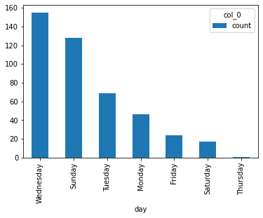

```python
#Visualisasi Hari Tweet
pd.crosstab(index = tweet_clean['day'] , columns = 'count').sort_values(by = 'count', ascending =False).plot(kind = 'bar')
```

Terlihat cukup unik dimana jumlah tweet terbanyak dilakukan pada hari rabu baru disusul kemudian hari minggu dan selasa.

Dugaan sejalan dengan informasi terbaru resmi dari FIFA (as per hari Rabu, 29 Maret 2023) mengenai berita pembatalan penyelenggaran U20 di Indonesia.

[figure not shown]

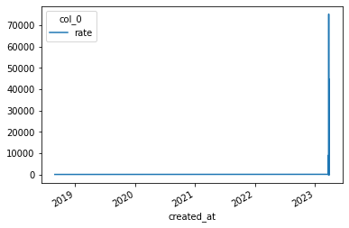

```python
#Visualisasi Engagement
#Dengan rumus Engagement = reply count + like + retweet +  quote tweet

#Subset hanya column yang dibutuhkan
tweet_baru = tweet_clean[['retweet_count', 'reply_count', 'favorite_count', 'quote_count', 'created_at', 'full_text']]

#Pilih column yang ingin dijumlahkan
column_names = ['retweet_count', 'quote_count', 'favorite_count', 'reply_count']
tweet_baru['engagement']= tweet_baru[column_names].sum(axis=1)
# tweet_baru['engagement'] = tweet_baru['retweet_count'] +  tweet_baru['quote_count'] +  tweet_baru['favorite_count'] + tweet_baru['reply_count']

pd.crosstab(index = tweet_baru['created_at'], columns= 'rate', values=tweet_baru['engagement'] , aggfunc='sum').plot()
```

Terlihat bahwa engagement tersebar hingga 2019 karena banyak retweet yang diambil sampai tahun tersebut

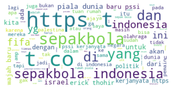

```python
#WordCloud
#Melihat kata yang sering muncul
text = tweet_clean['full_text'].tolist()

# join the list and lowercase all the words
text = ' '.join(text).lower()

#create the wordcloud object
wordcloud = WordCloud(max_font_size=50, max_words=100, background_color="white").generate(text)

#plot the wordcloud object
plt.imshow(wordcloud, interpolation='bilInear')
plt.axis('off')
plt.show()
```

Supaya tidak conflict, tweet_clean dari sepakbola akan dicopy (atau diubah) namanya menjadi tweet_sepakbola

```python
tweet_sepakbola = tweet_clean.copy()
tweet_sepakbola = tweet_sepakbola[['full_text', 'created_at']]
tweet_sepakbola
```

|  | full_text | created_at |
| --- | --- | --- |
| 0 | Instagram Story dari dua calon pemain Naturali... | 2023-03-29 16:26:14+00:00 |
| 1 | 🚨🚨🚨\n\n𝐁𝐑𝐄𝐀𝐊𝐈𝐍𝐆: Piala Dunia U-20 2023 telah r... | 2023-03-29 15:07:18+00:00 |
| 2 | Kalian koar-koar tentang kemanusiaan di Negara... | 2023-03-28 09:55:25+00:00 |
| 3 | Lini Masa Piala Dunia U-20 2023!🇮🇩🥹, Written b... | 2023-03-29 15:58:32+00:00 |
| 4 | Selamat hari Kamis semua, selamat beraktivitas... | 2023-03-29 21:32:04+00:00 |
| ... | ... | ... |
| 435 | Erick Thohir berkomitmen untuk memberikan duku... | 2023-03-26 09:00:00+00:00 |
| 436 | Dengan pengalamannya yang luas di dunia olahra... | 2023-03-26 09:00:01+00:00 |
| 437 | Salah satu misi besar Erick Thohir adalah memp... | 2023-03-26 09:00:02+00:00 |
| 438 | Dengan kehadiran pak Erick Thohir dan janji un... | 2023-03-26 09:00:02+00:00 |
| 439 | Yakin banget kalo pak ET bisa mengubah wajah s... | 2023-03-26 09:00:02+00:00 |

440 rows × 2 columns

Dari sekian banyak kata yang muncul dengan ukuran yang relatif besar, kata 'israel' menjadi kata pembeda yang dapat dibilang sering dibahas pada tweet mengenai sepakbola.

#### Prediksi Sentimen pada Tweet

Tahapan selanjutnya adalah mengetahui sentimen pada setiap tweet.

Berikut kita gunakan data twitter lain yang sudah diberi label sentimen yaitu:

```
- 0 untuk sentimen Positif dan,
- 1 untuk sentimen Negatif
```

```python
tweet = pd.read_csv("data_input/tweet_indonesian.csv", index_col = 0)
tweet = tweet.dropna()
tweet.head()
```

|  | sentimen | Tweet |
| --- | --- | --- |
| 5328.0 | 0.0 | doa rezeki tak putus inna haa zaa larizquna ma... |
| 5329.0 | 0.0 | makasih loh ntar kita bagi hasil aku 99 9 sisa... |
| 5330.0 | 0.0 | ya aku akan menjadi satu satunya bukan nomor s... |
| 5331.0 | 0.0 | i dont know why but these zikir sangat membant... |
| 5332.0 | 0.0 | aah kamu aja mas aku lebih suka diayomi |

```python
#Periksa proporsional kelas positif dan negatif
tweet['sentimen'].value_counts()
```

```
1.0    4188
0.0    2792
Name: sentimen, dtype: int64
```

Data tersebut harus "dibersihkan" terlebih dahulu sebelum dapat diproses lanjutan, teks diubah menjadi format corpus kemudian dibersihkan.

```python
tweet_clean = tweet['Tweet'].replace('\s+', ' ', regex=True)  # replace white space
tweet_clean=tweet_clean.replace('\.+', '', regex=True) #replace titik

special_char_list = [':', ';', '?', '}', ')', '{', '(']

for special_char in special_char_list:
    tweet_clean=tweet_clean.replace(special_char, '')

tweet_clean = tweet_clean.replace('((www\.[\s]+)|(https?://[^\s]+))','URL',regex=True) #replace url
tweet_clean =tweet_clean.replace(r'#([^\s]+)', r'\1', regex=True) # replace hashtag
tweet_clean =tweet_clean.replace('\s+', ' ', regex=True)

vectorizer = TfidfVectorizer(max_features=1000)

v_data = vectorizer.fit_transform(tweet_clean.values.astype('U')).toarray()

print (v_data)
```

```
[[0. 0. 0. ... 0. 0. 0.]
 [0. 0. 0. ... 0. 0. 0.]
 [0. 0. 0. ... 0. 0. 0.]
 ...
 [0. 0. 0. ... 0. 0. 0.]
 [0. 0. 0. ... 0. 0. 0.]
 [0. 0. 0. ... 0. 0. 0.]]
```

Kemudian kita akan menggunakan algoritma klasifikasi Naive-Bayes untuk melakukan prediksi sentimen

```python
X_train, X_test, y_train, y_test = train_test_split(v_data, tweet['sentimen'], test_size=0.2, random_state=0)

model = MultinomialNB()
model.fit(X_train,y_train)
```

```
MultinomialNB()
```

#### Evaluasi Model

```python
y_preds = model.predict(X_test)

print(confusion_matrix(y_test,y_preds))
print(classification_report(y_test,y_preds))
```

```
[[317 241]
 [ 98 740]]
              precision    recall  f1-score   support

         0.0       0.76      0.57      0.65       558
         1.0       0.75      0.88      0.81       838

    accuracy                           0.76      1396
   macro avg       0.76      0.73      0.73      1396
weighted avg       0.76      0.76      0.75      1396
```

```python
# lakukan preprocesing yang sama saat test model tweet Sepakbola

tweet_more_clean = tweet_sepakbola['full_text'].replace('\s+', ' ', regex=True)  # replace white space
tweet_more_clean_2=tweet_more_clean.replace('\.+', '', regex=True) #replace titik

special_char_list = [':', ';', '?', '}', ')', '{', '(']

for special_char in special_char_list:
    tweet_more_clean2=tweet_more_clean_2.replace(special_char, '')

tweet_more_clean2 = tweet_more_clean2.replace('((www\.[\s]+)|(https?://[^\s]+))','URL',regex=True) #replace url
tweet_more_clean2 =tweet_more_clean2.replace(r'#([^\s]+)', r'\1', regex=True) # replace hashtag
tweet_more_clean2 =tweet_more_clean2.replace('\s+', ' ', regex=True)

vectorizer2 = TfidfVectorizer(max_features=1000)

v_data2 = vectorizer2.fit_transform(tweet_more_clean2.values.astype('U')).toarray()

#predick untuk mendapatkan sentimen dari hasil scrap

model.predict(v_data2)
```

[output not shown]

```python
X_train, X_test, y_train, y_test = train_test_split(v_data, tweet['sentimen'], test_size=0.2, random_state=0)

model = MultinomialNB()
model.fit(X_train,y_train)
```

```
MultinomialNB()
```

```python
#untuk menyesuaikan panjang data test(tweet sepakbola) dengan y_test dari data tweet, maka perlu disesuaikan jumlah rownya
y_test_custom = y_test.head(n=440)
```

```python
y_preds = model.predict(v_data2)
y_preds
print(confusion_matrix(y_test_custom,y_preds))
print(classification_report(y_test_custom,y_preds))
```

```
[[ 46 128]
 [ 68 198]]
              precision    recall  f1-score   support

         0.0       0.40      0.26      0.32       174
         1.0       0.61      0.74      0.67       266

    accuracy                           0.55       440
   macro avg       0.51      0.50      0.49       440
weighted avg       0.53      0.55      0.53       440
```

Dari hasil pemeriksaan Confussion Matrix, didapat besaran angka:

`True Positive` sebanyak 46,

`True Negative` sebanyak 198,

Untuk keseluruhan prediksi, akurasinya hanya sebesar 0.55 atau 55%.

F1 score sendiri untuk masing-masing kelas juga rendah (0.32 dan 0.67), ini menandakan masih menghasilkan hasil prediksi yang buruk.

Dugaan rendahnya akurasi dan parameter lain pada model disebabkan oleh kurang cukupnya data yang digunakan untuk training sehingga masih besar kemungkinan terjadinya misclassify